# Hands-on Time Series Analysis with R

Author

Rick Dean

Abstract

The following notes/scripts/plots are inspired by chapter 5 ‘Decomposition of Time Series’ of the book [Hands-on Time Series Analysis with R](https://github.com/PacktPublishing/Hands-On-Time-Series-Analysis-with-R) by Rami Krispin

```r
library(data.table)
library(here)
library(magrittr)
library(xts)
library(RplotterPkg)
library(RtsaPkg)
```

# 5 Decomposition of time series data

## 5.1 The moving average function

Components of a moving average:

1. rolling window – generic function that slides across the series to extract sequential subsets.
2. average function – a simple or weighted average, which is applied on each subset of the rolling window.

### 5.1.1 The rolling window structure

The window structures include:

1. one-sided window – groups each observation of the series with its past $n-1$ observations. The first $n-1$ observations cannot be smoothed.
2. two-sised window – groups each observation of the series with past $n_{1}$ and future $n_{2}$ observations where $n$ = $n_{1}$ + $n_{2}$ + 1. If $n$ is odd then $n_{1}$ equals $n_{2}$. The $n-1/2$ observations on either end of the series cannot be smoothed.

### 5.1.2 The average method

Two types of averaging methods:

1. The simple mean where.

$$\bar{Y} = \frac{\sum^n_{i=1}Y_{i}}{n}$$
2. The weighted average.

$$\bar{Y} = \frac{\sum^n_{i=1}w_{i}Y_{i}}{n}$$

> A weighted average should be used with time series data when there is systematic relationship between some observations/variables in the series based on their timestamp distance (i.g. correlation analysis).

### 5.1.3 The MA attributes

The length of the MA window $n$ is known as the “order”.

The cost of MA window are the observations that cannot be averaged because of the definition of the window. For one-sided windows the cost is the first $n-1$ observations; for two-sided, the $n-1/2$ observations on either end of the series.

Main applications of MA are:

1. Noise reduction – reduces the series variation, smoothing the random noise
2. De-seasonalize – remove the seasonal component
3. Forecasting – forecast the future of the series by averaging the past observations

The term “MA” refers to the smoothing function; the term “MA model” or “MA process” refers to the regression analysis of the error term in forecasting.

We will use the “ts” time series USVSales to demonstrate the applications of each method.

Show the time series stats of USVSales and plot.

```r
apath <- file.path(here::here(), "Hands-on Time Series Analysis with R", "data", "USVSales.rda")
load(apath)
str(USVSales)
```

```
 Time-Series [1:528] from 1976 to 2020: 885 995 1244 1191 1203 ...
```

```r
RplotterPkg::create_table(
  x = RtsaPkg::get_series_info(series = USVSales)$stats,
  container_width_px = 400
)
```

| name | class | delta | start | end | freq | length | nvar |
| --- | --- | --- | --- | --- | --- | --- | --- |
| USVSales | ts | 0.08333333 | 1976 1 | 2019 12 | 12 | 528 | 1 |

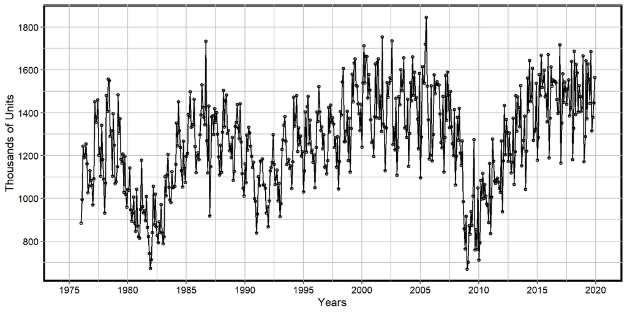

US Monthly Total Vehicle Sales

```r
USVSales_dt <- RtsaPkg::tsObj_to_dt(USVSales) %>%
  data.table::setnames(old = c("time", "value"), new = c("Date", "USVSales"))
RplotterPkg::create_scatter_plot(
  df = USVSales_dt,
  aes_x = "Date",
  aes_y = "USVSales",
  x_title = "Years",
  y_title = "Thousands of Units",
  rot_y_tic_label = T,
  connect = T,
  x_limits = c(as.Date("1975-01-01"), as.Date("2020-01-01")),
  x_major_breaks = seq.Date(from = as.Date("1975-1-1"), to = as.Date("2020-1-1"), by = "5 year"),
  x_date_labels = "%Y",
  y_major_breaks = seq(from = 600, to = 2000, by = 200)
)
```

### 5.1.4 The simple moving average

Compute the simple moving average of USVSales using window order equal to 4.

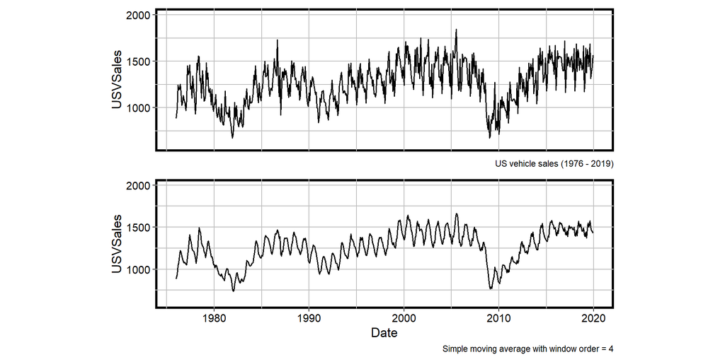

Simple moving average of US vehicle sales, order = 4

```r
RtsaPkg::graph_ma(
  df = USVSales_dt,
  time_col = "Date",
  value_col = "USVSales",
  overlap = FALSE,
  show_pts = FALSE,
  y_limits = c(600, 2000),
  ma_caption = "Simple moving average with window order = 4",
  ob_caption = "US vehicle sales (1976 - 2019)",
  row_height = 6
)
```

Compute the simple moving average of USVSales using window order equal to 12.

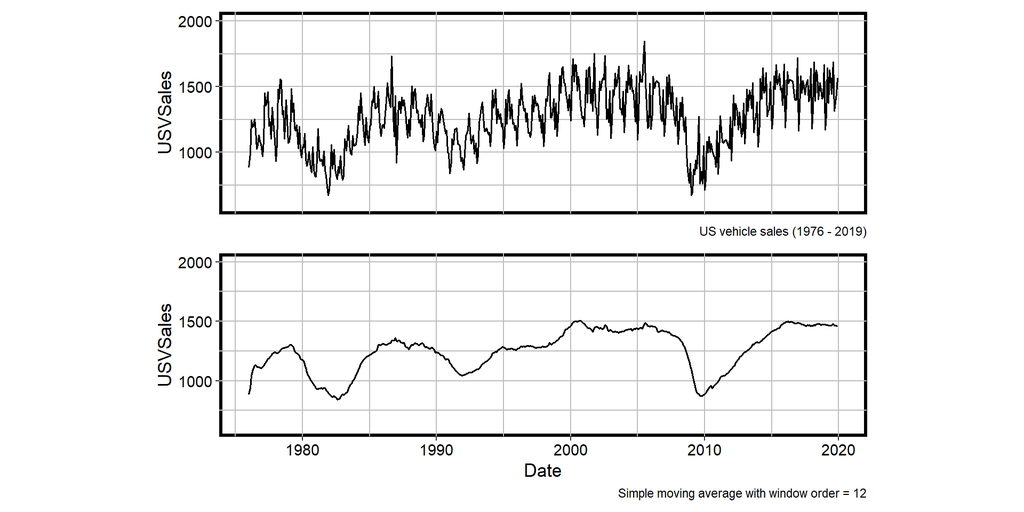

Simple moving average of US vehicle sales, order = 12

```r
RtsaPkg::graph_ma(
  df = USVSales_dt,
  time_col = "Date",
  value_col = "USVSales",
  window_n = 12,
  overlap = FALSE,
  show_pts = FALSE,
  y_limits = c(600, 2000),
  ma_caption = "Simple moving average with window order = 12",
  ob_caption = "US vehicle sales (1976 - 2019)",
  row_height = 6
)
```